# Risk Factor Analysis

## Outcome Variable

**Outcome Variable:** ever_swasted

## Predictor Variables

**Intervention Variable:** parity

**Adjustment Set:**

unadjusted

## Stratifying Variables

The analysis was stratified on these variable(s):

- agecat
- studyid
- country

## Data Summary

| agecat | studyid | country | parity | ever_swasted | n_cell | n |
| --- | --- | --- | --- | --- | --- | --- |
| 0-24 months | ki1000304b-SAS-CompFeed | INDIA | 1 | 0 | 400 | 1513 |
| 0-24 months | ki1000304b-SAS-CompFeed | INDIA | 1 | 1 | 48 | 1513 |
| 0-24 months | ki1000304b-SAS-CompFeed | INDIA | 2 | 0 | 300 | 1513 |
| 0-24 months | ki1000304b-SAS-CompFeed | INDIA | 2 | 1 | 54 | 1513 |
| 0-24 months | ki1000304b-SAS-CompFeed | INDIA | 3+ | 0 | 590 | 1513 |
| 0-24 months | ki1000304b-SAS-CompFeed | INDIA | 3+ | 1 | 121 | 1513 |
| 0-24 months | ki1000304b-SAS-FoodSuppl | INDIA | 1 | 0 | 17 | 418 |
| 0-24 months | ki1000304b-SAS-FoodSuppl | INDIA | 1 | 1 | 4 | 418 |
| 0-24 months | ki1000304b-SAS-FoodSuppl | INDIA | 2 | 0 | 70 | 418 |
| 0-24 months | ki1000304b-SAS-FoodSuppl | INDIA | 2 | 1 | 7 | 418 |
| 0-24 months | ki1000304b-SAS-FoodSuppl | INDIA | 3+ | 0 | 260 | 418 |
| 0-24 months | ki1000304b-SAS-FoodSuppl | INDIA | 3+ | 1 | 60 | 418 |
| 0-24 months | ki1017093b-PROVIDE | BANGLADESH | 1 | 0 | 252 | 700 |
| 0-24 months | ki1017093b-PROVIDE | BANGLADESH | 1 | 1 | 19 | 700 |
| 0-24 months | ki1017093b-PROVIDE | BANGLADESH | 2 | 0 | 236 | 700 |
| 0-24 months | ki1017093b-PROVIDE | BANGLADESH | 2 | 1 | 8 | 700 |
| 0-24 months | ki1017093b-PROVIDE | BANGLADESH | 3+ | 0 | 170 | 700 |
| 0-24 months | ki1017093b-PROVIDE | BANGLADESH | 3+ | 1 | 15 | 700 |
| 0-24 months | ki1066203-TanzaniaChild2 | TANZANIA, UNITED REPUBLIC OF | 1 | 0 | 767 | 2357 |
| 0-24 months | ki1066203-TanzaniaChild2 | TANZANIA, UNITED REPUBLIC OF | 1 | 1 | 54 | 2357 |
| 0-24 months | ki1066203-TanzaniaChild2 | TANZANIA, UNITED REPUBLIC OF | 2 | 0 | 717 | 2357 |
| 0-24 months | ki1066203-TanzaniaChild2 | TANZANIA, UNITED REPUBLIC OF | 2 | 1 | 54 | 2357 |
| 0-24 months | ki1066203-TanzaniaChild2 | TANZANIA, UNITED REPUBLIC OF | 3+ | 0 | 716 | 2357 |
| 0-24 months | ki1066203-TanzaniaChild2 | TANZANIA, UNITED REPUBLIC OF | 3+ | 1 | 49 | 2357 |
| 0-24 months | ki1101329-Keneba | GAMBIA | 1 | 0 | 195 | 1990 |
| 0-24 months | ki1101329-Keneba | GAMBIA | 1 | 1 | 45 | 1990 |
| 0-24 months | ki1101329-Keneba | GAMBIA | 2 | 0 | 175 | 1990 |
| 0-24 months | ki1101329-Keneba | GAMBIA | 2 | 1 | 39 | 1990 |
| 0-24 months | ki1101329-Keneba | GAMBIA | 3+ | 0 | 1222 | 1990 |
| 0-24 months | ki1101329-Keneba | GAMBIA | 3+ | 1 | 314 | 1990 |

[output cut: 168 more lines]

The following strata were considered:

- agecat: 0-24 months, studyid: ki1000304b-SAS-CompFeed, country: INDIA
- agecat: 0-24 months, studyid: ki1000304b-SAS-FoodSuppl, country: INDIA
- agecat: 0-24 months, studyid: ki1017093b-PROVIDE, country: BANGLADESH
- agecat: 0-24 months, studyid: ki1066203-TanzaniaChild2, country: TANZANIA, UNITED REPUBLIC OF
- agecat: 0-24 months, studyid: ki1101329-Keneba, country: GAMBIA
- agecat: 0-24 months, studyid: ki1113344-GMS-Nepal, country: NEPAL
- agecat: 0-24 months, studyid: ki1126311-ZVITAMBO, country: ZIMBABWE
- agecat: 0-24 months, studyid: ki1135781-COHORTS, country: GUATEMALA
- agecat: 0-24 months, studyid: ki1135781-COHORTS, country: INDIA
- agecat: 0-24 months, studyid: ki1135781-COHORTS, country: PHILIPPINES
- agecat: 0-24 months, studyid: kiGH5241-JiVitA-3, country: BANGLADESH
- agecat: 0-6 months, studyid: ki1000304b-SAS-CompFeed, country: INDIA
- agecat: 0-6 months, studyid: ki1000304b-SAS-FoodSuppl, country: INDIA
- agecat: 0-6 months, studyid: ki1017093b-PROVIDE, country: BANGLADESH
- agecat: 0-6 months, studyid: ki1066203-TanzaniaChild2, country: TANZANIA, UNITED REPUBLIC OF
- agecat: 0-6 months, studyid: ki1101329-Keneba, country: GAMBIA
- agecat: 0-6 months, studyid: ki1113344-GMS-Nepal, country: NEPAL
- agecat: 0-6 months, studyid: ki1126311-ZVITAMBO, country: ZIMBABWE
- agecat: 0-6 months, studyid: ki1135781-COHORTS, country: GUATEMALA
- agecat: 0-6 months, studyid: ki1135781-COHORTS, country: INDIA
- agecat: 0-6 months, studyid: ki1135781-COHORTS, country: PHILIPPINES
- agecat: 0-6 months, studyid: kiGH5241-JiVitA-3, country: BANGLADESH
- agecat: 6-24 months, studyid: ki1000304b-SAS-CompFeed, country: INDIA
- agecat: 6-24 months, studyid: ki1000304b-SAS-FoodSuppl, country: INDIA
- agecat: 6-24 months, studyid: ki1017093b-PROVIDE, country: BANGLADESH
- agecat: 6-24 months, studyid: ki1066203-TanzaniaChild2, country: TANZANIA, UNITED REPUBLIC OF
- agecat: 6-24 months, studyid: ki1101329-Keneba, country: GAMBIA
- agecat: 6-24 months, studyid: ki1113344-GMS-Nepal, country: NEPAL
- agecat: 6-24 months, studyid: ki1126311-ZVITAMBO, country: ZIMBABWE
- agecat: 6-24 months, studyid: ki1135781-COHORTS, country: GUATEMALA
- agecat: 6-24 months, studyid: ki1135781-COHORTS, country: INDIA
- agecat: 6-24 months, studyid: ki1135781-COHORTS, country: PHILIPPINES
- agecat: 6-24 months, studyid: kiGH5241-JiVitA-3, country: BANGLADESH

### Dropped Strata

Some strata were dropped due to rare outcomes:

- agecat: 0-24 months, studyid: ki1000304b-SAS-FoodSuppl, country: INDIA
- agecat: 0-6 months, studyid: ki1000304b-SAS-FoodSuppl, country: INDIA
- agecat: 0-6 months, studyid: ki1017093b-PROVIDE, country: BANGLADESH
- agecat: 6-24 months, studyid: ki1000304b-SAS-FoodSuppl, country: INDIA
- agecat: 6-24 months, studyid: ki1017093b-PROVIDE, country: BANGLADESH

## Methods Detail

We’re interested in the causal parameters $E[Y_a]$ for all values of $a \in \mathcal{A}$. These parameters represent the mean outcome if, possibly contrary to fact, we intervened to set all units to have $A=a$. Under the randomization and positivity assumptions, these are identified by the statistical parameters $\psi_a=E_W[E_{Y|A,W}(Y|A=a,W)]$. In addition, we’re interested in the mean of $Y$, $E[Y]$ under no intervention (the observed mean). We will estimate these parameters by using SuperLearner to fit the relevant likelihood factors – $E_{Y|A,W}(Y|A=a,W)$ and $p(A=a|W)$, and then updating our likelihood fit using a joint TMLE.

For unadjusted analyses ($W=\{\}$), initial likelihoods were estimated using Lrnr_glm to estimate the simple $E(Y|A)$ and Lrnr_mean to estimate $p(A)$. For adjusted analyses, a small library containing Lrnr_glmnet, Lrnr_xgboost, and Lrnr_mean was used.

Having estimated these parameters, we will then use the delta method to estimate relative risks and attributable risks relative to a prespecified baseline level of $A$.

# Results Detail

## Results Plots

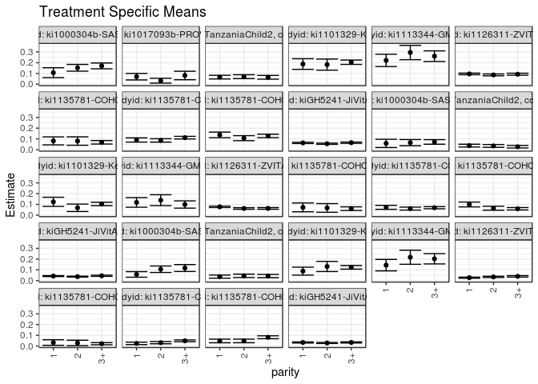

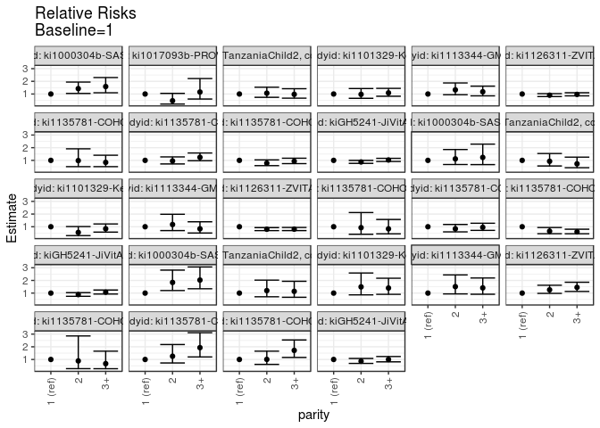

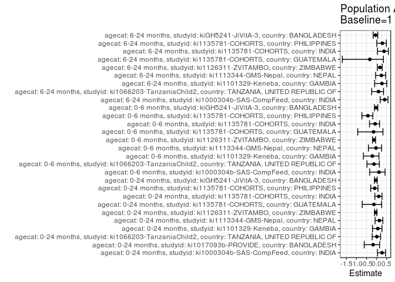

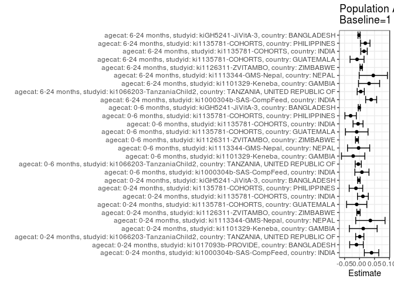

## Results Table

### Parameter: TSM

| agecat | studyid | country | intervention_level | baseline_level | estimate | ci_lower | ci_upper |
| --- | --- | --- | --- | --- | --- | --- | --- |
| 0-24 months | ki1000304b-SAS-CompFeed | INDIA | 1 | NA | 0.1071429 | 0.0611715 | 0.1531142 |
| 0-24 months | ki1000304b-SAS-CompFeed | INDIA | 2 | NA | 0.1525424 | 0.1210961 | 0.1839887 |
| 0-24 months | ki1000304b-SAS-CompFeed | INDIA | 3+ | NA | 0.1701828 | 0.1429957 | 0.1973699 |
| 0-24 months | ki1017093b-PROVIDE | BANGLADESH | 1 | NA | 0.0701107 | 0.0396891 | 0.1005323 |
| 0-24 months | ki1017093b-PROVIDE | BANGLADESH | 2 | NA | 0.0327869 | 0.0104267 | 0.0551470 |
| 0-24 months | ki1017093b-PROVIDE | BANGLADESH | 3+ | NA | 0.0810811 | 0.0417196 | 0.1204425 |
| 0-24 months | ki1066203-TanzaniaChild2 | TANZANIA, UNITED REPUBLIC OF | 1 | NA | 0.0657734 | 0.0488137 | 0.0827332 |
| 0-24 months | ki1066203-TanzaniaChild2 | TANZANIA, UNITED REPUBLIC OF | 2 | NA | 0.0700389 | 0.0520206 | 0.0880573 |
| 0-24 months | ki1066203-TanzaniaChild2 | TANZANIA, UNITED REPUBLIC OF | 3+ | NA | 0.0640523 | 0.0466982 | 0.0814064 |
| 0-24 months | ki1101329-Keneba | GAMBIA | 1 | NA | 0.1875000 | 0.1381072 | 0.2368928 |
| 0-24 months | ki1101329-Keneba | GAMBIA | 2 | NA | 0.1822430 | 0.1305076 | 0.2339784 |
| 0-24 months | ki1101329-Keneba | GAMBIA | 3+ | NA | 0.2044271 | 0.1842541 | 0.2246001 |
| 0-24 months | ki1113344-GMS-Nepal | NEPAL | 1 | NA | 0.2216749 | 0.1644934 | 0.2788564 |
| 0-24 months | ki1113344-GMS-Nepal | NEPAL | 2 | NA | 0.2944444 | 0.2278104 | 0.3610784 |
| 0-24 months | ki1113344-GMS-Nepal | NEPAL | 3+ | NA | 0.2607261 | 0.2112565 | 0.3101957 |
| 0-24 months | ki1126311-ZVITAMBO | ZIMBABWE | 1 | NA | 0.0957376 | 0.0882961 | 0.1031791 |
| 0-24 months | ki1126311-ZVITAMBO | ZIMBABWE | 2 | NA | 0.0866443 | 0.0781139 | 0.0951747 |
| 0-24 months | ki1126311-ZVITAMBO | ZIMBABWE | 3+ | NA | 0.0927945 | 0.0835213 | 0.1020676 |
| 0-24 months | ki1135781-COHORTS | GUATEMALA | 1 | NA | 0.0817308 | 0.0444868 | 0.1189748 |
| 0-24 months | ki1135781-COHORTS | GUATEMALA | 2 | NA | 0.0802139 | 0.0412684 | 0.1191594 |
| 0-24 months | ki1135781-COHORTS | GUATEMALA | 3+ | NA | 0.0687104 | 0.0525847 | 0.0848360 |
| 0-24 months | ki1135781-COHORTS | INDIA | 1 | NA | 0.0901235 | 0.0704009 | 0.1098460 |
| 0-24 months | ki1135781-COHORTS | INDIA | 2 | NA | 0.0861486 | 0.0701648 | 0.1021325 |
| 0-24 months | ki1135781-COHORTS | INDIA | 3+ | NA | 0.1117871 | 0.0997431 | 0.1238311 |
| 0-24 months | ki1135781-COHORTS | PHILIPPINES | 1 | NA | 0.1373708 | 0.1114359 | 0.1633056 |
| 0-24 months | ki1135781-COHORTS | PHILIPPINES | 2 | NA | 0.1070381 | 0.0838314 | 0.1302448 |
| 0-24 months | ki1135781-COHORTS | PHILIPPINES | 3+ | NA | 0.1281139 | 0.1121581 | 0.1440697 |
| 0-24 months | kiGH5241-JiVitA-3 | BANGLADESH | 1 | NA | 0.0631049 | 0.0575829 | 0.0686269 |
| 0-24 months | kiGH5241-JiVitA-3 | BANGLADESH | 2 | NA | 0.0551824 | 0.0496712 | 0.0606937 |
| 0-24 months | kiGH5241-JiVitA-3 | BANGLADESH | 3+ | NA | 0.0649696 | 0.0588805 | 0.0710587 |

[output cut: 54 more lines]

### Parameter: E(Y)

| agecat | studyid | country | intervention_level | baseline_level | estimate | ci_lower | ci_upper |
| --- | --- | --- | --- | --- | --- | --- | --- |
| 0-24 months | ki1000304b-SAS-CompFeed | INDIA | NA | NA | 0.1473893 | 0.1184132 | 0.1763654 |
| 0-24 months | ki1017093b-PROVIDE | BANGLADESH | NA | NA | 0.0600000 | 0.0423945 | 0.0776055 |
| 0-24 months | ki1066203-TanzaniaChild2 | TANZANIA, UNITED REPUBLIC OF | NA | NA | 0.0666101 | 0.0565417 | 0.0766785 |
| 0-24 months | ki1101329-Keneba | GAMBIA | NA | NA | 0.2000000 | 0.1824211 | 0.2175789 |
| 0-24 months | ki1113344-GMS-Nepal | NEPAL | NA | NA | 0.2580175 | 0.2252514 | 0.2907836 |
| 0-24 months | ki1126311-ZVITAMBO | ZIMBABWE | NA | NA | 0.0922194 | 0.0874171 | 0.0970218 |
| 0-24 months | ki1135781-COHORTS | GUATEMALA | NA | NA | 0.0723341 | 0.0584645 | 0.0862036 |
| 0-24 months | ki1135781-COHORTS | INDIA | NA | NA | 0.1014273 | 0.0927249 | 0.1101298 |
| 0-24 months | ki1135781-COHORTS | PHILIPPINES | NA | NA | 0.1254516 | 0.1136848 | 0.1372183 |
| 0-24 months | kiGH5241-JiVitA-3 | BANGLADESH | NA | NA | 0.0610254 | 0.0575469 | 0.0645038 |
| 0-6 months | ki1000304b-SAS-CompFeed | INDIA | NA | NA | 0.0664452 | 0.0425975 | 0.0902929 |
| 0-6 months | ki1066203-TanzaniaChild2 | TANZANIA, UNITED REPUBLIC OF | NA | NA | 0.0335172 | 0.0262496 | 0.0407848 |
| 0-6 months | ki1101329-Keneba | GAMBIA | NA | NA | 0.1026472 | 0.0888174 | 0.1164771 |
| 0-6 months | ki1113344-GMS-Nepal | NEPAL | NA | NA | 0.1151604 | 0.0912555 | 0.1390652 |
| 0-6 months | ki1126311-ZVITAMBO | ZIMBABWE | NA | NA | 0.0687987 | 0.0645835 | 0.0730139 |
| 0-6 months | ki1135781-COHORTS | GUATEMALA | NA | NA | 0.0630292 | 0.0484135 | 0.0776449 |
| 0-6 months | ki1135781-COHORTS | INDIA | NA | NA | 0.0675068 | 0.0601293 | 0.0748842 |
| 0-6 months | ki1135781-COHORTS | PHILIPPINES | NA | NA | 0.0693167 | 0.0602923 | 0.0783411 |
| 0-6 months | kiGH5241-JiVitA-3 | BANGLADESH | NA | NA | 0.0413642 | 0.0383846 | 0.0443438 |
| 6-24 months | ki1000304b-SAS-CompFeed | INDIA | NA | NA | 0.0964723 | 0.0729872 | 0.1199573 |
| 6-24 months | ki1066203-TanzaniaChild2 | TANZANIA, UNITED REPUBLIC OF | NA | NA | 0.0412682 | 0.0325201 | 0.0500164 |
| 6-24 months | ki1101329-Keneba | GAMBIA | NA | NA | 0.1200624 | 0.1055350 | 0.1345898 |
| 6-24 months | ki1113344-GMS-Nepal | NEPAL | NA | NA | 0.1898305 | 0.1581595 | 0.2215015 |
| 6-24 months | ki1126311-ZVITAMBO | ZIMBABWE | NA | NA | 0.0329203 | 0.0295572 | 0.0362834 |
| 6-24 months | ki1135781-COHORTS | GUATEMALA | NA | NA | 0.0247321 | 0.0159885 | 0.0334756 |
| 6-24 months | ki1135781-COHORTS | INDIA | NA | NA | 0.0403319 | 0.0344774 | 0.0461863 |
| 6-24 months | ki1135781-COHORTS | PHILIPPINES | NA | NA | 0.0669277 | 0.0576848 | 0.0761707 |
| 6-24 months | kiGH5241-JiVitA-3 | BANGLADESH | NA | NA | 0.0319690 | 0.0290813 | 0.0348568 |

### Parameter: RR

| agecat | studyid | country | intervention_level | baseline_level | estimate | ci_lower | ci_upper |
| --- | --- | --- | --- | --- | --- | --- | --- |
| 0-24 months | ki1000304b-SAS-CompFeed | INDIA | 1 | 1 | 1.0000000 | 1.0000000 | 1.0000000 |
| 0-24 months | ki1000304b-SAS-CompFeed | INDIA | 2 | 1 | 1.4237288 | 1.0432777 | 1.9429187 |
| 0-24 months | ki1000304b-SAS-CompFeed | INDIA | 3+ | 1 | 1.5883732 | 1.0979497 | 2.2978550 |
| 0-24 months | ki1017093b-PROVIDE | BANGLADESH | 1 | 1 | 1.0000000 | 1.0000000 | 1.0000000 |
| 0-24 months | ki1017093b-PROVIDE | BANGLADESH | 2 | 1 | 0.4676445 | 0.2083855 | 1.0494558 |
| 0-24 months | ki1017093b-PROVIDE | BANGLADESH | 3+ | 1 | 1.1564723 | 0.6030613 | 2.2177317 |
| 0-24 months | ki1066203-TanzaniaChild2 | TANZANIA, UNITED REPUBLIC OF | 1 | 1 | 1.0000000 | 1.0000000 | 1.0000000 |
| 0-24 months | ki1066203-TanzaniaChild2 | TANZANIA, UNITED REPUBLIC OF | 2 | 1 | 1.0648508 | 0.7397776 | 1.5327679 |
| 0-24 months | ki1066203-TanzaniaChild2 | TANZANIA, UNITED REPUBLIC OF | 3+ | 1 | 0.9738320 | 0.6699577 | 1.4155352 |
| 0-24 months | ki1101329-Keneba | GAMBIA | 1 | 1 | 1.0000000 | 1.0000000 | 1.0000000 |
| 0-24 months | ki1101329-Keneba | GAMBIA | 2 | 1 | 0.9719626 | 0.6598685 | 1.4316660 |
| 0-24 months | ki1101329-Keneba | GAMBIA | 3+ | 1 | 1.0902778 | 0.8229397 | 1.4444626 |
| 0-24 months | ki1113344-GMS-Nepal | NEPAL | 1 | 1 | 1.0000000 | 1.0000000 | 1.0000000 |
| 0-24 months | ki1113344-GMS-Nepal | NEPAL | 2 | 1 | 1.3282716 | 0.9424496 | 1.8720422 |
| 0-24 months | ki1113344-GMS-Nepal | NEPAL | 3+ | 1 | 1.1761643 | 0.8538841 | 1.6200821 |
| 0-24 months | ki1126311-ZVITAMBO | ZIMBABWE | 1 | 1 | 1.0000000 | 1.0000000 | 1.0000000 |
| 0-24 months | ki1126311-ZVITAMBO | ZIMBABWE | 2 | 1 | 0.9050188 | 0.7983267 | 1.0259698 |
| 0-24 months | ki1126311-ZVITAMBO | ZIMBABWE | 3+ | 1 | 0.9692584 | 0.8539986 | 1.1000743 |
| 0-24 months | ki1135781-COHORTS | GUATEMALA | 1 | 1 | 1.0000000 | 1.0000000 | 1.0000000 |
| 0-24 months | ki1135781-COHORTS | GUATEMALA | 2 | 1 | 0.9814407 | 0.5042893 | 1.9100662 |
| 0-24 months | ki1135781-COHORTS | GUATEMALA | 3+ | 1 | 0.8406915 | 0.5035327 | 1.4036071 |
| 0-24 months | ki1135781-COHORTS | INDIA | 1 | 1 | 1.0000000 | 1.0000000 | 1.0000000 |
| 0-24 months | ki1135781-COHORTS | INDIA | 2 | 1 | 0.9558960 | 0.7174788 | 1.2735388 |
| 0-24 months | ki1135781-COHORTS | INDIA | 3+ | 1 | 1.2403771 | 0.9718946 | 1.5830270 |
| 0-24 months | ki1135781-COHORTS | PHILIPPINES | 1 | 1 | 1.0000000 | 1.0000000 | 1.0000000 |
| 0-24 months | ki1135781-COHORTS | PHILIPPINES | 2 | 1 | 0.7791915 | 0.5845074 | 1.0387198 |
| 0-24 months | ki1135781-COHORTS | PHILIPPINES | 3+ | 1 | 0.9326139 | 0.7438336 | 1.1693055 |
| 0-24 months | kiGH5241-JiVitA-3 | BANGLADESH | 1 | 1 | 1.0000000 | 1.0000000 | 1.0000000 |
| 0-24 months | kiGH5241-JiVitA-3 | BANGLADESH | 2 | 1 | 0.8744561 | 0.7651288 | 0.9994050 |
| 0-24 months | kiGH5241-JiVitA-3 | BANGLADESH | 3+ | 1 | 1.0295496 | 0.9133802 | 1.1604942 |

[output cut: 54 more lines]

### Parameter: PAR

| agecat | studyid | country | intervention_level | baseline_level | estimate | ci_lower | ci_upper |
| --- | --- | --- | --- | --- | --- | --- | --- |
| 0-24 months | ki1000304b-SAS-CompFeed | INDIA | 1 | NA | 0.0402464 | 0.0160860 | 0.0644069 |
| 0-24 months | ki1017093b-PROVIDE | BANGLADESH | 1 | NA | -0.0101107 | -0.0328889 | 0.0126675 |
| 0-24 months | ki1066203-TanzaniaChild2 | TANZANIA, UNITED REPUBLIC OF | 1 | NA | 0.0008367 | -0.0128975 | 0.0145708 |
| 0-24 months | ki1101329-Keneba | GAMBIA | 1 | NA | 0.0125000 | -0.0339781 | 0.0589781 |
| 0-24 months | ki1113344-GMS-Nepal | NEPAL | 1 | NA | 0.0363426 | -0.0127308 | 0.0854160 |
| 0-24 months | ki1126311-ZVITAMBO | ZIMBABWE | 1 | NA | -0.0035182 | -0.0090624 | 0.0020261 |
| 0-24 months | ki1135781-COHORTS | GUATEMALA | 1 | NA | -0.0093967 | -0.0432962 | 0.0245028 |
| 0-24 months | ki1135781-COHORTS | INDIA | 1 | NA | 0.0113039 | -0.0068189 | 0.0294266 |
| 0-24 months | ki1135781-COHORTS | PHILIPPINES | 1 | NA | -0.0119192 | -0.0345463 | 0.0107079 |
| 0-24 months | kiGH5241-JiVitA-3 | BANGLADESH | 1 | NA | -0.0020795 | -0.0062492 | 0.0020902 |
| 0-6 months | ki1000304b-SAS-CompFeed | INDIA | 1 | NA | 0.0080182 | -0.0156131 | 0.0316495 |
| 0-6 months | ki1066203-TanzaniaChild2 | TANZANIA, UNITED REPUBLIC OF | 1 | NA | -0.0042416 | -0.0144598 | 0.0059765 |
| 0-6 months | ki1101329-Keneba | GAMBIA | 1 | NA | -0.0212844 | -0.0603192 | 0.0177504 |
| 0-6 months | ki1113344-GMS-Nepal | NEPAL | 1 | NA | -0.0030663 | -0.0401853 | 0.0340528 |
| 0-6 months | ki1126311-ZVITAMBO | ZIMBABWE | 1 | NA | -0.0085373 | -0.0134541 | -0.0036204 |
| 0-6 months | ki1135781-COHORTS | GUATEMALA | 1 | NA | -0.0093393 | -0.0471037 | 0.0284252 |
| 0-6 months | ki1135781-COHORTS | INDIA | 1 | NA | -0.0049570 | -0.0216440 | 0.0117300 |
| 0-6 months | ki1135781-COHORTS | PHILIPPINES | 1 | NA | -0.0297957 | -0.0488632 | -0.0107283 |
| 0-6 months | kiGH5241-JiVitA-3 | BANGLADESH | 1 | NA | -0.0007704 | -0.0042174 | 0.0026766 |
| 6-24 months | ki1000304b-SAS-CompFeed | INDIA | 1 | NA | 0.0389183 | 0.0204764 | 0.0573603 |
| 6-24 months | ki1066203-TanzaniaChild2 | TANZANIA, UNITED REPUBLIC OF | 1 | NA | 0.0041211 | -0.0078130 | 0.0160553 |
| 6-24 months | ki1101329-Keneba | GAMBIA | 1 | NA | 0.0319566 | -0.0034041 | 0.0673174 |
| 6-24 months | ki1113344-GMS-Nepal | NEPAL | 1 | NA | 0.0461179 | -0.0011406 | 0.0933765 |
| 6-24 months | ki1126311-ZVITAMBO | ZIMBABWE | 1 | NA | 0.0056272 | 0.0017203 | 0.0095342 |
| 6-24 months | ki1135781-COHORTS | GUATEMALA | 1 | NA | -0.0082350 | -0.0316403 | 0.0151703 |
| 6-24 months | ki1135781-COHORTS | INDIA | 1 | NA | 0.0150995 | 0.0043190 | 0.0258800 |
| 6-24 months | ki1135781-COHORTS | PHILIPPINES | 1 | NA | 0.0192304 | 0.0034747 | 0.0349861 |
| 6-24 months | kiGH5241-JiVitA-3 | BANGLADESH | 1 | NA | -0.0015354 | -0.0051840 | 0.0021133 |

### Parameter: PAF

| agecat | studyid | country | intervention_level | baseline_level | estimate | ci_lower | ci_upper |
| --- | --- | --- | --- | --- | --- | --- | --- |
| 0-24 months | ki1000304b-SAS-CompFeed | INDIA | 1 | NA | 0.2730621 | 0.0480619 | 0.4448813 |
| 0-24 months | ki1017093b-PROVIDE | BANGLADESH | 1 | NA | -0.1685117 | -0.6132761 | 0.1536356 |
| 0-24 months | ki1066203-TanzaniaChild2 | TANZANIA, UNITED REPUBLIC OF | 1 | NA | 0.0125604 | -0.2167250 | 0.1986382 |
| 0-24 months | ki1101329-Keneba | GAMBIA | 1 | NA | 0.0625000 | -0.2011839 | 0.2683000 |
| 0-24 months | ki1113344-GMS-Nepal | NEPAL | 1 | NA | 0.1408533 | -0.0716135 | 0.3111947 |
| 0-24 months | ki1126311-ZVITAMBO | ZIMBABWE | 1 | NA | -0.0381499 | -0.1000176 | 0.0202382 |
| 0-24 months | ki1135781-COHORTS | GUATEMALA | 1 | NA | -0.1299068 | -0.7098785 | 0.2533449 |
| 0-24 months | ki1135781-COHORTS | INDIA | 1 | NA | 0.1114481 | -0.0862109 | 0.2731388 |
| 0-24 months | ki1135781-COHORTS | PHILIPPINES | 1 | NA | -0.0950103 | -0.2909022 | 0.0711554 |
| 0-24 months | kiGH5241-JiVitA-3 | BANGLADESH | 1 | NA | -0.0340761 | -0.1046680 | 0.0320049 |
| 0-6 months | ki1000304b-SAS-CompFeed | INDIA | 1 | NA | 0.1206742 | -0.3413032 | 0.4235353 |
| 0-6 months | ki1066203-TanzaniaChild2 | TANZANIA, UNITED REPUBLIC OF | 1 | NA | -0.1265514 | -0.4751575 | 0.1396728 |
| 0-6 months | ki1101329-Keneba | GAMBIA | 1 | NA | -0.2073549 | -0.6533219 | 0.1183169 |
| 0-6 months | ki1113344-GMS-Nepal | NEPAL | 1 | NA | -0.0266259 | -0.4052413 | 0.2499788 |
| 0-6 months | ki1126311-ZVITAMBO | ZIMBABWE | 1 | NA | -0.1240908 | -0.1975185 | -0.0551654 |
| 0-6 months | ki1135781-COHORTS | GUATEMALA | 1 | NA | -0.1481736 | -0.9334049 | 0.3181446 |
| 0-6 months | ki1135781-COHORTS | INDIA | 1 | NA | -0.0734300 | -0.3512595 | 0.1472756 |
| 0-6 months | ki1135781-COHORTS | PHILIPPINES | 1 | NA | -0.4298494 | -0.7277015 | -0.1833464 |
| 0-6 months | kiGH5241-JiVitA-3 | BANGLADESH | 1 | NA | -0.0186246 | -0.1054420 | 0.0613745 |
| 6-24 months | ki1000304b-SAS-CompFeed | INDIA | 1 | NA | 0.4034146 | 0.1777945 | 0.5671226 |
| 6-24 months | ki1066203-TanzaniaChild2 | TANZANIA, UNITED REPUBLIC OF | 1 | NA | 0.0998623 | -0.2401896 | 0.3466742 |
| 6-24 months | ki1101329-Keneba | GAMBIA | 1 | NA | 0.2661669 | -0.0941166 | 0.5078121 |
| 6-24 months | ki1113344-GMS-Nepal | NEPAL | 1 | NA | 0.2429427 | -0.0488562 | 0.4535612 |
| 6-24 months | ki1126311-ZVITAMBO | ZIMBABWE | 1 | NA | 0.1709348 | 0.0447453 | 0.2804547 |
| 6-24 months | ki1135781-COHORTS | GUATEMALA | 1 | NA | -0.3329670 | -1.6972387 | 0.3412518 |
| 6-24 months | ki1135781-COHORTS | INDIA | 1 | NA | 0.3743806 | 0.0489747 | 0.5884445 |
| 6-24 months | ki1135781-COHORTS | PHILIPPINES | 1 | NA | 0.2873303 | 0.0125714 | 0.4856356 |
| 6-24 months | kiGH5241-JiVitA-3 | BANGLADESH | 1 | NA | -0.0480266 | -0.1683804 | 0.0599297 |